# Plotting pitch

M. Sonderegger & XX

Last update: July 12

# 1 Preliminaries

Load packages and data output by the PolyglotDB formants tutorial script:

```r
library(tidyverse)
library(broom)

v <- read_csv("librispeech_pitch_full_set.csv")
```

## 1.1 Preprocessing

Save original dataset:

```r
v_orig <- v
```

Quick look at columns of the dataframe:

```r
glimpse(v)
```

```
## Rows: 30,210
## Columns: 15
## $ traj_id                      <chr> "fcb0eac8-fcdb-11ec-b292-fc4dd44cd2b1", "…
## $ vowel                        <chr> "AH1", "AH1", "AH1", "AH1", "AH0", "AH0",…
## $ consonant                    <chr> "B", "B", "B", "B", "DH", "DH", "DH", "DH…
## $ following_phone              <chr> "T", "T", "T", "T", "R", "R", "R", "R", "…
## $ word                         <chr> "but", "but", "but", "but", "the", "the",…
## $ word_duration                <dbl> 0.13, 0.13, 0.13, 0.13, 0.17, 0.17, 0.17,…
## $ word_transcription           <chr> "B.AH1.T", "B.AH1.T", "B.AH1.T", "B.AH1.T…
## $ following_word_transcription <chr> "T.AH0", "T.AH0", "T.AH0", "T.AH0", "R.IH…
## $ begin                        <dbl> 12.69, 12.69, 12.69, 12.69, 5.73, 5.73, 5…
## $ end                          <dbl> 12.73, 12.73, 12.73, 12.73, 5.84, 5.84, 5…
## $ discourse                    <chr> "1089-134691-0013", "1089-134691-0013", "…
## $ speaker                      <dbl> 1089, 1089, 1089, 1089, 1089, 1089, 1089,…
## $ sex                          <chr> "M", "M", "M", "M", "M", "M", "M", "M", "…
## $ time                         <dbl> 12.695, 12.705, 12.715, 12.725, 5.740, 5.…
## $ F0                           <dbl> -1.00, -1.00, -1.00, -1.00, 102.25, 102.1…
```

We just want data from words beginning with CV. There are some words starting with VV, which is a bug in the query. Exclude these:

```r
v <- filter(v, !(consonant %in% c("AW1", "OW1", "ER0"))) %>% droplevels()
```

We are primarily interested in:

- `F0`: pitch (in Hz), where -1 means “undefined” (unvoiced frame of speech)
- `sex` of speaker
- `speaker`
- `consonant`: consonant preceding the vowel

Define and correct some columns:

- `stress`: this is e.g. `1` in `AH1`
- `stressed`: stress = 0 vs 2/1
- `vowel`: this is e.g. `AH` in `AH`
- `speaker`: should be character (or factor)
- `rel_time`: time since beginning of vowel

```r
v <- v %>% mutate(
  stress = str_split(vowel, "[A-Z]+", simplify = TRUE)[, 2],
  stressed = ifelse(stress == "0", "N", "Y"),
  vowel = str_split(vowel, "[0-9]", simplify = TRUE)[, 1],
  speaker = as.character(speaker)
)

v <- v %>%
  group_by(traj_id) %>%
  summarize(min_time = min(time)) %>%
  left_join(v) %>%
  mutate(rel_time = time - min_time) %>%
  select(-min_time)
```

Below we’ll look at effects of consonant type and vowel height on F0. This requires defining:

1. Broad types of consonant

```r
v <- v %>%
  mutate(
    cons_class =
      fct_recode(
        consonant,
        voiced_obs = "B", voiced_obs = "DH", voiced_obs = "D", voiced_obs = "G", voiced_obs = "V", voiced_obs = "JH", voiced_obs = "Z",
        vless_obs = "CH", vless_obs = "F", vless_obs = "CH", vless_obs = "HH", vless_obs = "K", vless_obs = "P", vless_obs = "S", vless_obs = "SH", vless_obs = "T", vless_obs = "TH",
        nasal = "M", nasal = "N",
        sonorant = "L", sonorant = "R", sonorant = "W", sonorant = "Y"
      )
  )
```

2. Vowel height

```r
v <- v %>%
  mutate(
    vowel_height =
      fct_recode(
        vowel,
        high = "IY", high = "UH", high = "UW", high = "IH",
        mid = "EY", mid = "EH", mid = "ER", mid = "OW", mid = "AH",
        low = "AE", low = "AA", low = "AO",
        dipth = "OY", dipth = "AY", dipth = "AW"
      )
  )
```

Make pitch = -1 be NA:

```r
v[v$F0 == -1, "F0"] <- NA
```

Speaker mean pitch, and $z$-score pitch within speaker:

```r
v <- v %>%
  group_by(speaker) %>%
  summarize(F0_mean = mean(F0, na.rm = T)) %>%
  left_join(v) %>%
  group_by(speaker) %>%
  mutate(F0_std = as.numeric(scale(F0)))
```

Add vowel duration (I think), basic stats to be used to detect trajectories where pitch tracking was off.

```r
v <- v %>%
  group_by(traj_id) %>%
  summarise(
    dur = 0.010 * (n() - 1),
    ## number and % of NA points in this trajectory
    na_n = sum(is.na(F0)),
    not_na_n = n() - na_n,
    na_frac = na_n / n(),
  ) %>%
  left_join(v)
```

# 2 Data cleaning

All trajectories, filtering out those with non-trivial undefined F0:

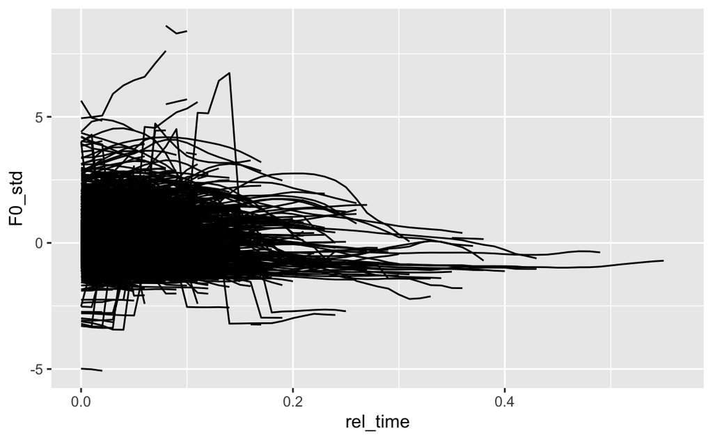

```r
v %>%
  ## filter out trajectories where any appreciable portion of vowel didn't have F0 detected:
  filter(na_frac < 0.1 & na_n <= 2) %>%
  ggplot(aes(x = rel_time, y = F0_std)) +
  geom_line(aes(group = traj_id))
```

There are some crazy trajectories there. For this demo, let’s just remove anything 3 SD from speaker mean or >200 msec long (which is a very long vowel):

```r
v <- v %>%
  filter(na_frac < 0.1 & na_n <= 2) %>%
  filter(abs(F0_std) < 3) %>%
  filter(dur < 0.2)
```

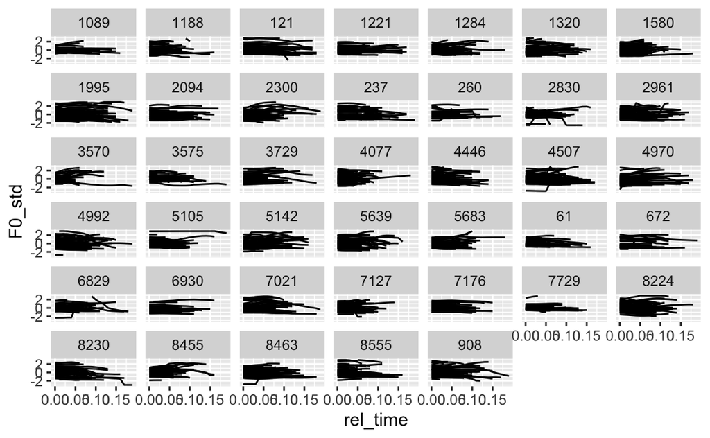

```r
v %>%
  filter(na_frac < 0.1 & na_n <= 2) %>%
  ggplot(aes(x = rel_time, y = F0_std)) +
  geom_line(aes(group = traj_id)) +
  facet_wrap(~speaker)
```

Looks a bit better.

How much data was excluded?

```r
## this percent
1 - nrow(v) / nrow(v_orig)
```

```
## [1] 0.3268454
```

# 3 Basic patterns

Examine in just stressed syllables, to avoid prosodic effects.

## 3.1 Consonant voicing

Voiced vs. voiceless obstruent trajectories as a function of % through the vowel:

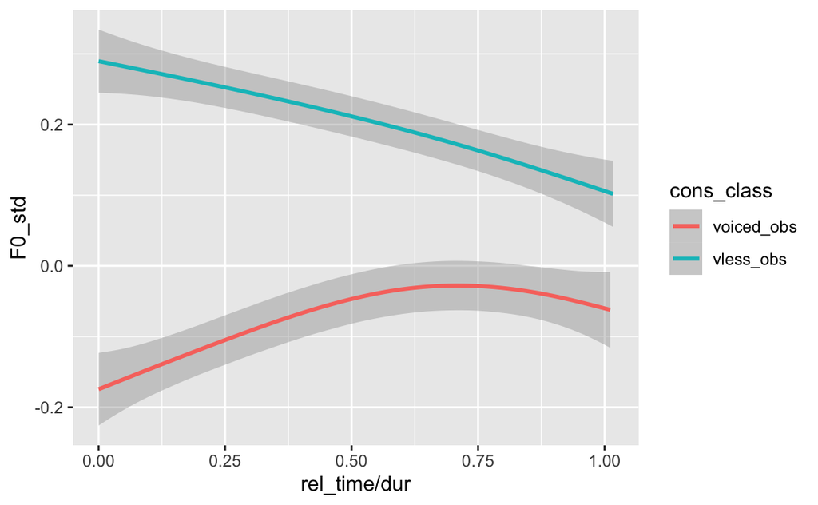

```r
v %>%
  filter(stressed == "Y" & cons_class %in% c("voiced_obs", "vless_obs")) %>%
  ggplot(aes(x = rel_time / dur, y = F0_std)) +
  geom_smooth(aes(color = cons_class))
```

Beautiful. In Hz, faceting by gender:

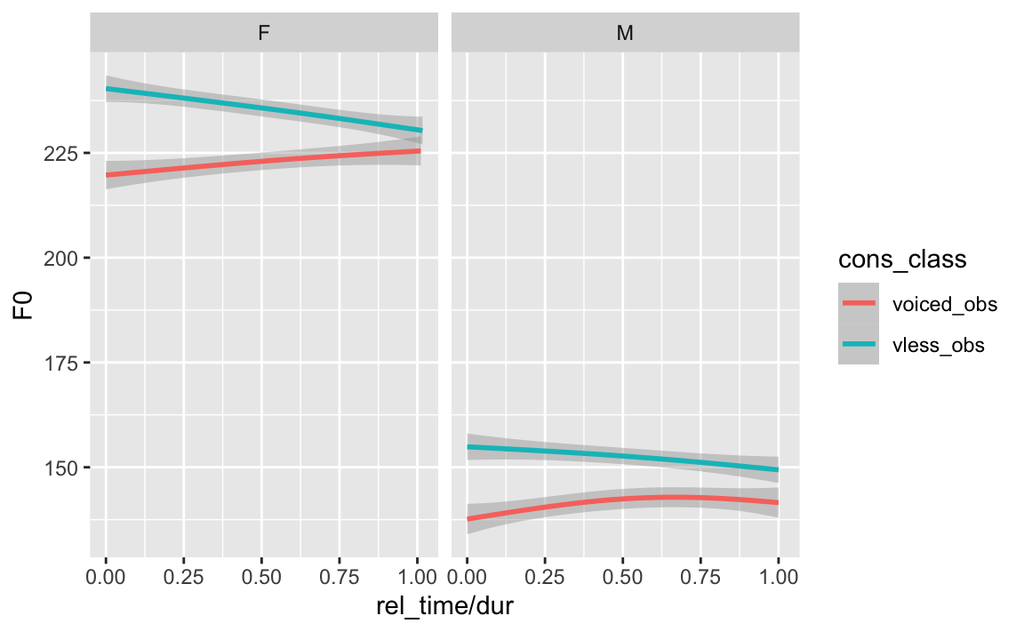

```r
v %>%
  filter(stressed == "Y" & cons_class %in% c("voiced_obs", "vless_obs")) %>%
  ggplot(aes(x = rel_time / dur, y = F0)) +
  geom_smooth(aes(color = cons_class)) +
  facet_wrap(~sex)
```

Now by-speaker:

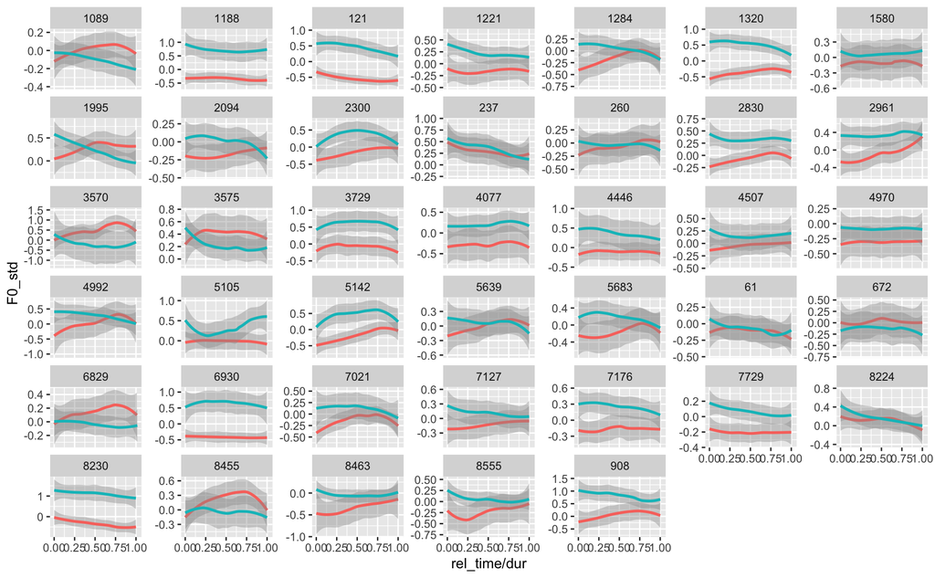

```r
v %>%
  filter(stressed == "Y" & cons_class %in% c("voiced_obs", "vless_obs")) %>%
  ggplot(aes(x = rel_time / dur, y = F0_std)) +
  geom_smooth(aes(color = cons_class)) +
  facet_wrap(~speaker, scales = "free_y") +
  theme(legend.position = "none")
```

Here there is some interesting variability, but most speakers show the expected pattern: blue $>$ red, at least at beginning of the vowel.

## 3.2 Vowel height

Trajectories as a function of vowel height, just for stressed syllables, omitting diphthongs (which don’t have a well-defined height):

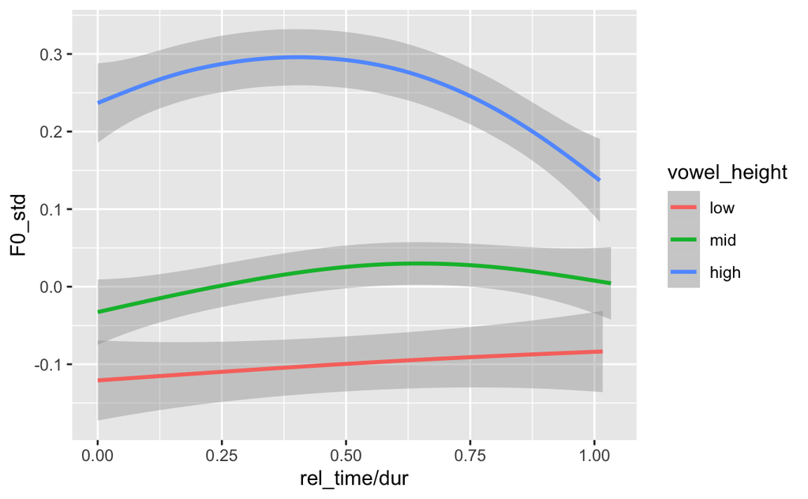

```r
v %>%
  filter(stressed == "Y" & vowel_height != "dipth") %>%
  droplevels() %>%
  ggplot(aes(x = rel_time / dur, y = F0_std)) +
  geom_smooth(aes(color = vowel_height))
```

Beautiful. In Hz, faceting by gender:

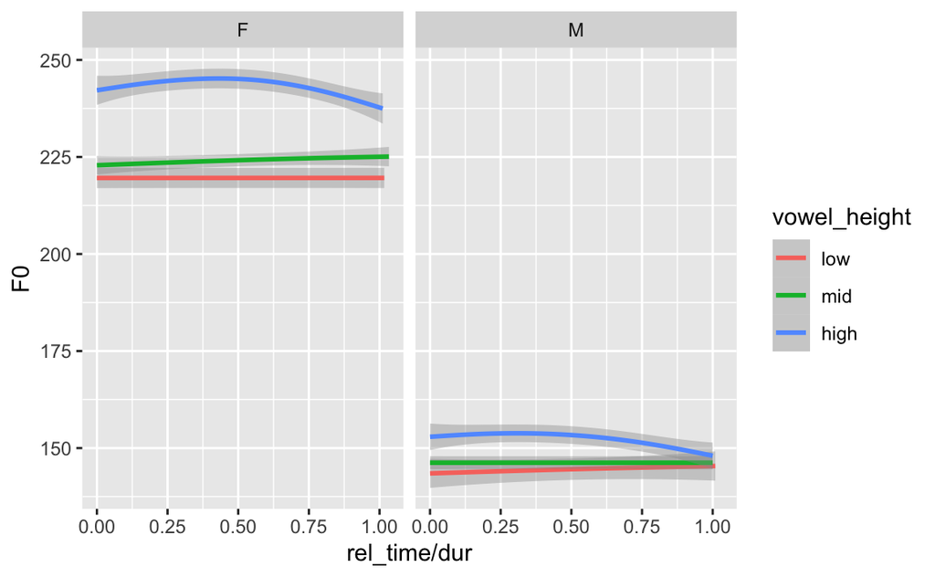

```r
v %>%
  filter(stressed == "Y" & vowel_height != "dipth") %>%
  droplevels() %>%
  ggplot(aes(x = rel_time / dur, y = F0)) +
  geom_smooth(aes(color = vowel_height)) +
  facet_wrap(~sex)
```

The effect is larger (in Hz) for F speakers than for M speakers, as expected.